# ggplot2 Exercise Solutions

Aubrey Odom-Mabey

2/14/2022

First, we’ll load the main tidyverse library.

```r
suppressPackageStartupMessages({
  library(tidyverse)
  library(magrittr)
})
```

# Exercise 1 - Simple point and line plots

## 1a) Weight Chart

```r
# We'll plot out the data in the weight_chart.txt file.
# Let's load it and look at it first.
wt <- read_delim("weight_chart.txt")
head(wt)
```

```
## # A tibble: 6 × 2
##     Age Weight
##   <dbl>  <dbl>
## 1     0    3.6
## 2     1    4.4
## 3     2    5.2
## 4     3    6
## 5     4    6.6
## 6     5    7.2
```

We’ll start with a simple plot, just setting the minimum aesthetics.

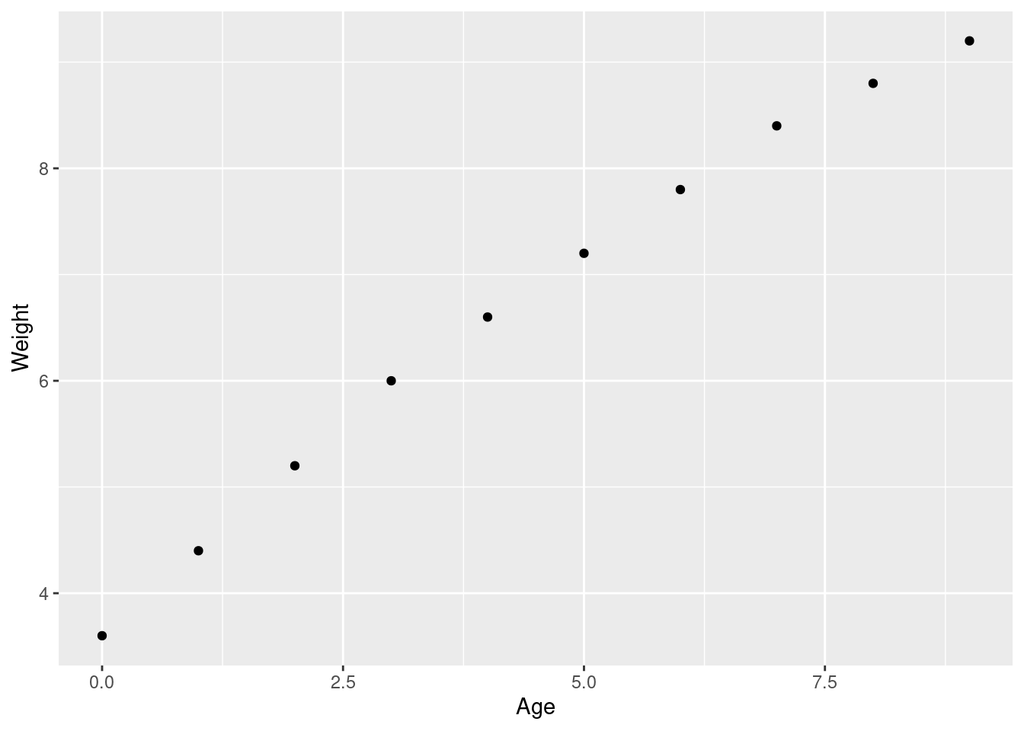

```r
wt %>%
ggplot(aes(x = Age, y = Weight)) +
  geom_point()
```

Now we can customize this a bit by adding fixed aesthetics to the `geom_point()` function.

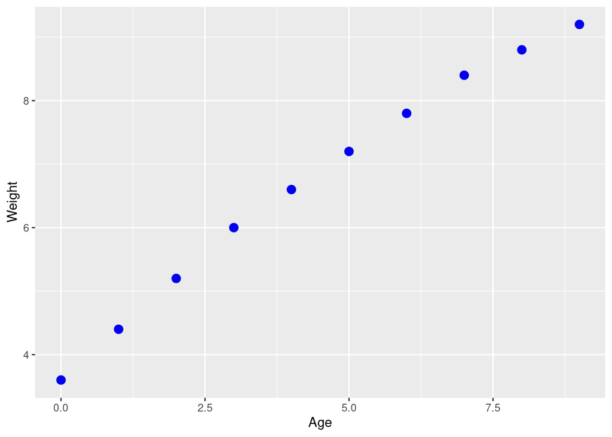

```r
wt %>%
ggplot(aes(x = Age, y = Weight)) +
  geom_point(col = "blue2", size = 3)
```

Now repeat, but with a different geometry.

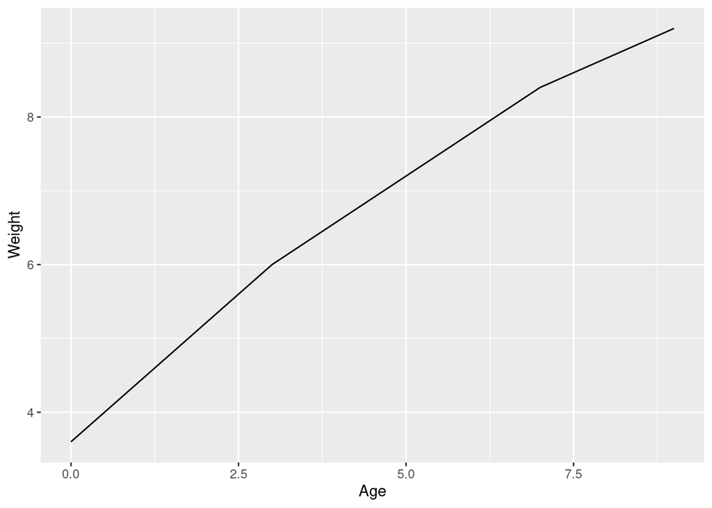

```r
wt %>%
ggplot(aes(x = Age, y = Weight)) +
  geom_line()
```

Finally, combine the two geometries.

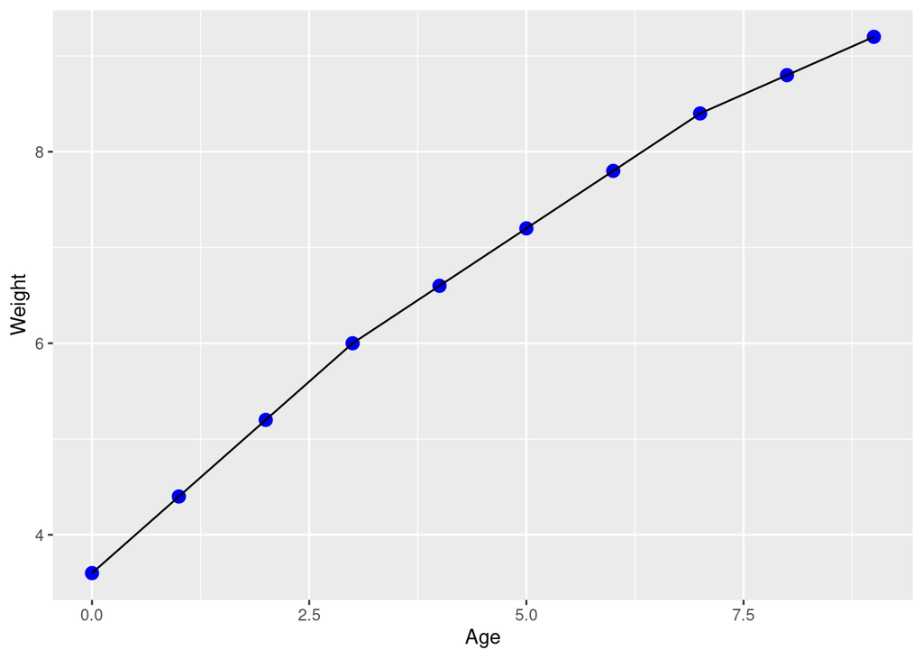

```r
wt %>%
ggplot(aes(x = Age, y = Weight)) +
  geom_point(col = "blue2", size = 3) +
  geom_line()
```

## 1b) Chromosome Position

Now let’s look at the `chromosome_position_data.txt` file.

```r
chr <- read_delim("chromosome_position_data.txt")
head(chr)
```

```
## # A tibble: 6 × 4
##   Position  Mut1  Mut2    WT
##      <dbl> <dbl> <dbl> <dbl>
## 1 91757273  2.71  1.34  1.25
## 2 91757323  2.71  1.3   1.25
## 3 91757373  5.41  1.14  1.25
## 4 91757423  2.71  1.58  1.88
## 5 91757473  2.71  1.19  1.25
## 6 91757523  2.71  2.82  2.5
```

We have the data in three separate columns at the moment so we need to use `pivot_longer` to put them into a single column.

```r
newchr <- chr %>%
  pivot_longer(cols = c("Mut1", "Mut2", "WT"), names_to = "Sample",
               values_to = "Value")

head(newchr)
```

```
## # A tibble: 6 × 3
##   Position Sample Value
##      <dbl> <chr>  <dbl>
## 1 91757273 Mut1    2.71
## 2 91757273 Mut2    1.34
## 3 91757273 WT      1.25
## 4 91757323 Mut1    2.71
## 5 91757323 Mut2    1.3
## 6 91757323 WT      1.25
```

Now we can plot out a line graph of the position vs value for each of the samples. We’ll use color to distiguish the lines for each sample.

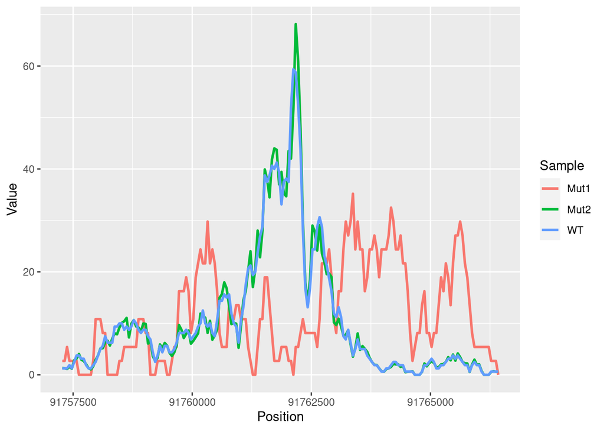

```r
newchr %>%
ggplot(aes(x = Position, y = Value, color = Sample)) +
  geom_line(size = 1)
```

## 1c) Genomes

Finally, we’re going to look at the genome size vs number of chromosomes and color it by domain in our genomes data.

```r
genomes <- read_csv("genomes.csv")
glimpse(genomes)
```

```
## Rows: 47,211
## Columns: 7
## $ Organism    <chr> "'Brassica napus' phytoplasma", "'Candidatus Kapabacteria'…
## $ Groups      <chr> "Bacteria;Terrabacteria group;Tenericutes", "Bacteria;FCB …
## $ Size        <dbl> 0.743598, 3.272990, 0.603949, 0.739592, 0.545427, 4.021830…
## $ Chromosomes <dbl> 0, 0, 1, 0, 0, 0, 0, 6, 1, 1, 0, 1, 0, 0, 0, 1, 0, 0, 0, 0…
## $ Organelles  <dbl> 0, 0, 0, 0, 0, 0, 0, 0, 0, 0, 0, 0, 0, 0, 0, 0, 0, 0, 0, 0…
## $ Plasmids    <dbl> 0, 0, 1, 0, 0, 0, 0, 0, 0, 0, 0, 0, 0, 0, 0, 0, 0, 0, 0, 0…
## $ Assemblies  <dbl> 1, 1, 1, 1, 1, 1, 1, 2, 1, 1, 1, 1, 1, 1, 1, 1, 1, 1, 1, 7…
```

To get at the Domain, we’ll need to split apart the Groups field.

```r
genomes %<>%
  separate(col = Groups, into = c("Domain", "Kingdom", "Class"), sep = ";")
```

Now we can draw the plot.

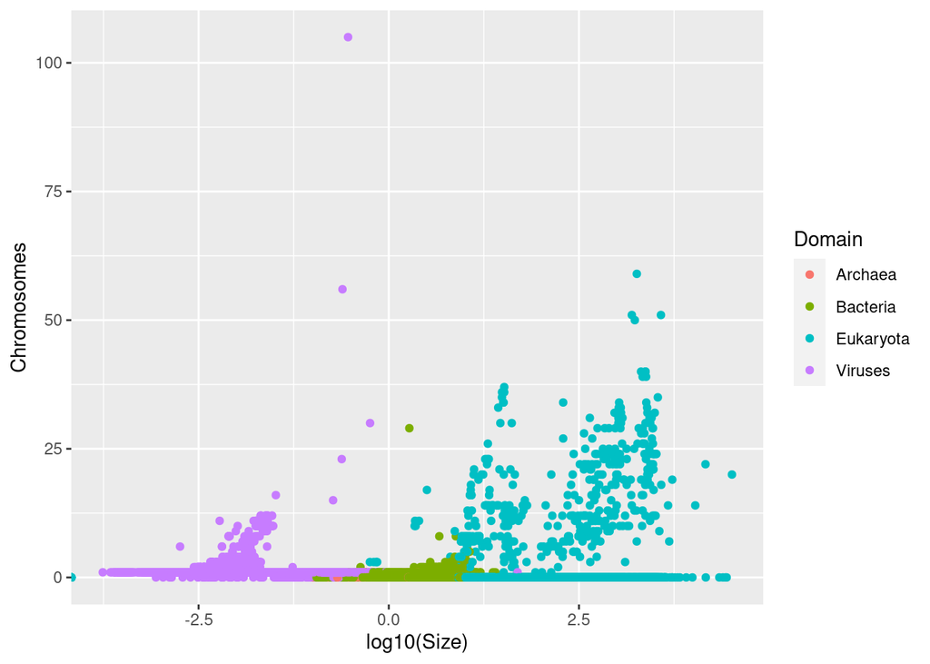

```r
genomes %>%
  ggplot(aes(x = log10(Size), y = Chromosomes, col = Domain)) +
  geom_point()
```

# Exercise 2 - Barplots and Distributions

## 2a) Small File

We want a barplot of the lengths of samples in category A.

```r
small_file <- read_tsv("small_file.txt")
head(small_file)
```

```
## # A tibble: 6 × 3
##   Sample Length Category
##   <chr>   <dbl> <chr>
## 1 x_1        45 A
## 2 x_2        82 B
## 3 x_3        81 C
## 4 x_4        56 D
## 5 x_5        96 A
## 6 x_6        85 B
```

Since there’s only one measure per sample, there is no summarizing to be done, so we use `geom_col` rather than `geom_bar`.

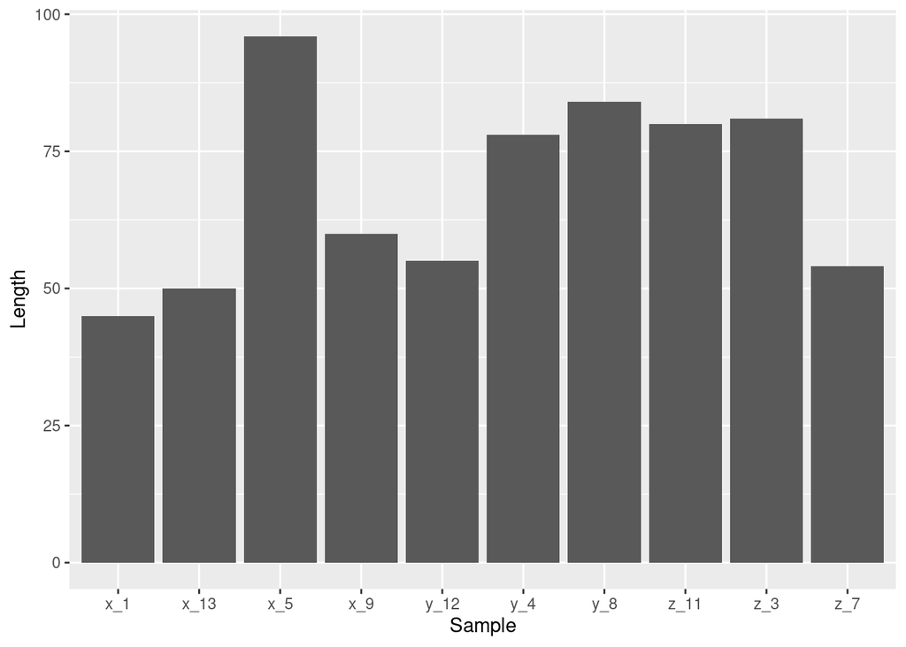

```r
small_file %>%
  filter(Category == "A") %>%
  ggplot(aes(x = Sample, y = Length)) +
  geom_col()
```

We will create a bar plot of the mean length for each category.

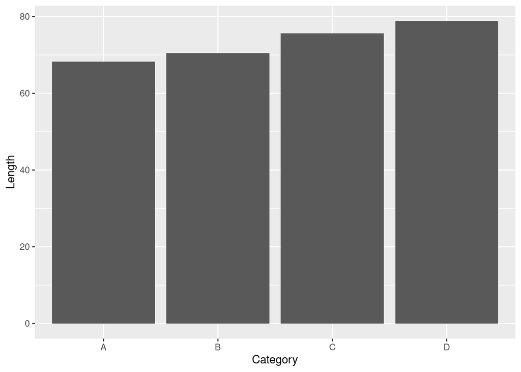

```r
small_file %>%
  ggplot(aes(x = Category, y = Length)) +
  geom_bar(stat = "summary", fun = "mean")
```

Next we want a chart (`geom_jitter`) of all of the lengths for each category. We need to use `height = 0` in the `geom_jitter` to ensure that we don’t adjust the height of the points, only their width.

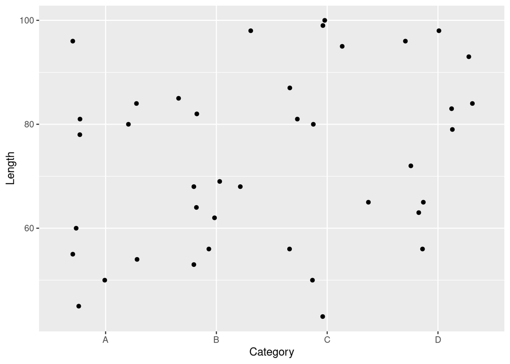

```r
set.seed(90)
small_file %>%
  ggplot(aes(x = Category, y = Length)) +
  geom_jitter(height = 0)
```

Whilst this worked it’s not very easy to tell the categories apart so we’ll tweak it to make it clearer.

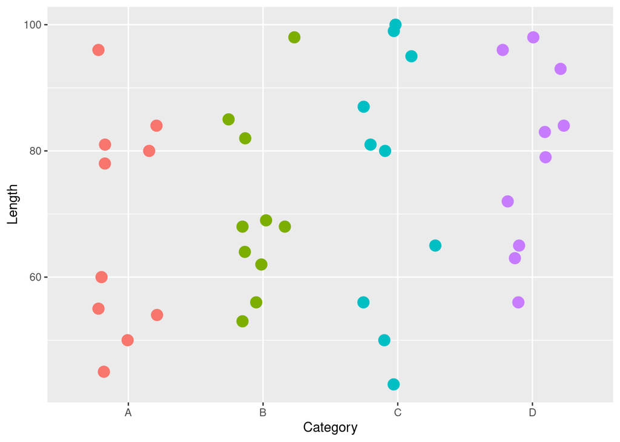

```r
set.seed(90)
small_file %>%
  ggplot(aes(x = Category, y = Length, color = Category)) +
  geom_jitter(height = 0, width = 0.3, show.legend = FALSE, size = 4)
```

## 2b) Expression Data

Plot the distribution of expression values.

```r
expression <- read_tsv("expression.txt")
head(expression)
```

```
## # A tibble: 6 × 2
##   Gene   Expression
##   <chr>       <dbl>
## 1 Xkr4        -5.04
## 2 Gm1992      -2.17
## 3 Rp1         -6.96
## 4 Sox17       -2.67
## 5 Mrpl15       3.35
## 6 Lypla1       1.83
```

Let’s try the plots in a couple of ways.

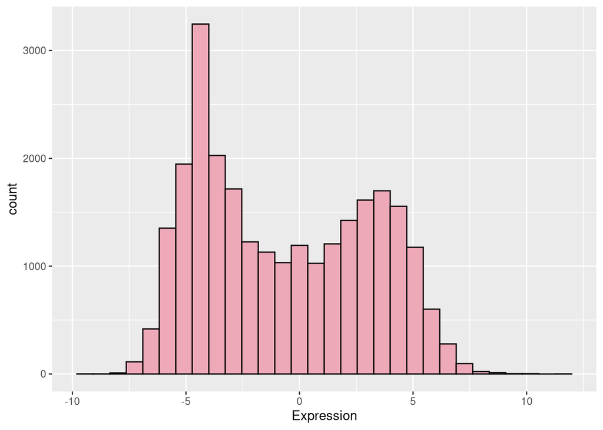

```r
expression %>%
  ggplot(aes(Expression)) +
  geom_histogram(fill = "pink2", color = "black", bins = 30)
```

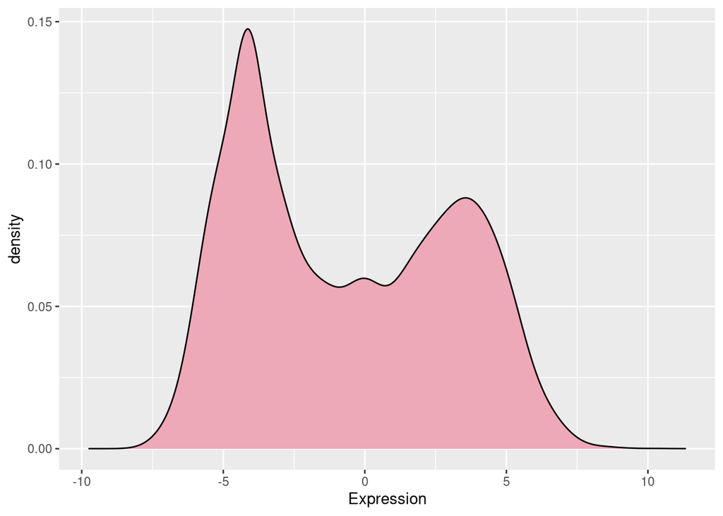

```r
expression %>%
  ggplot(aes(Expression)) +
  geom_density(fill = "pink2", color = "black")
```

We could also play around with the resolution in either of these plots.

Either increasing the resolution:

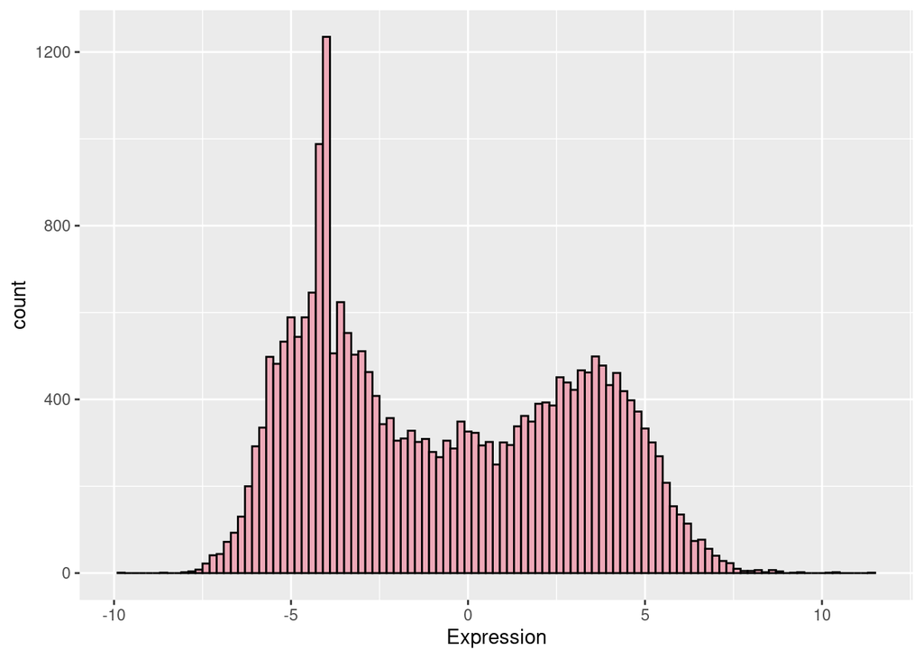

```r
expression %>%
  ggplot(aes(Expression)) +
  geom_histogram(fill = "pink2", color = "black", binwidth = 0.2)
```

..or decreasing it.

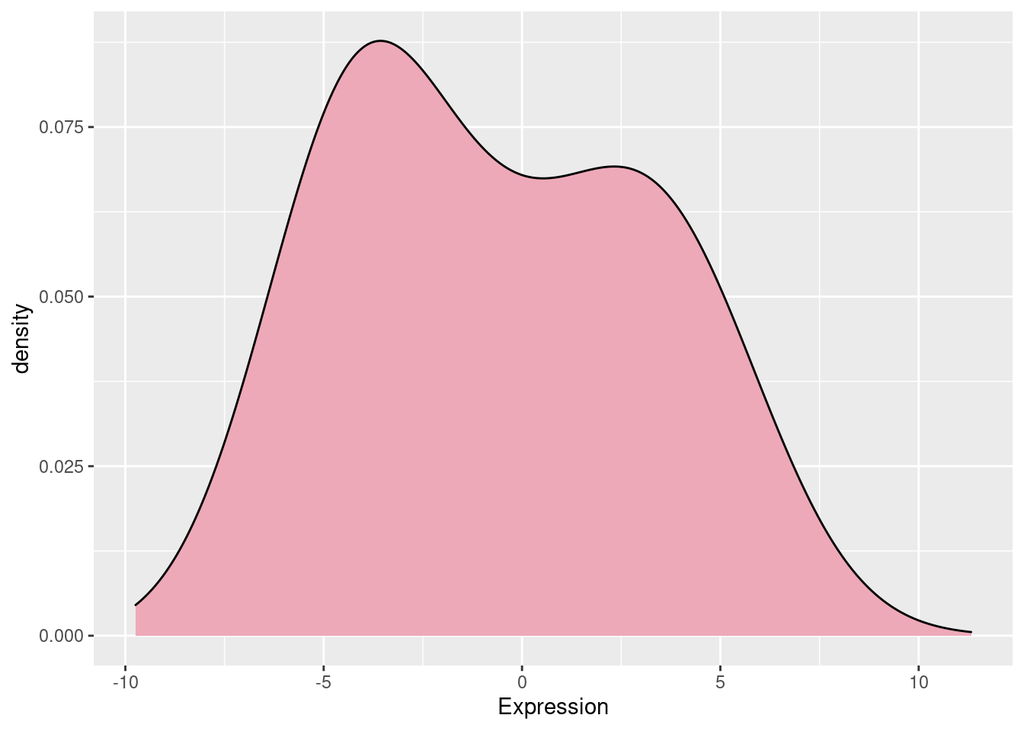

```r
expression %>%
  ggplot(aes(Expression)) +
  geom_density(fill = "pink2", color = "black", bw = 2)
```

## 2c) Cancer

Plot the number of male deaths for all sites.

```r
cancer <- read_csv("cancer_stats.csv")
head(cancer)
```

```
## # A tibble: 6 × 6
##   Class      Site      `Male Cases` `Female Cases` `Male Deaths` `Female Deaths`
##   <chr>      <chr>            <dbl>          <dbl>         <dbl>           <dbl>
## 1 Oral       Tongue           12550           4510          2220             800
## 2 Oral       Mouth             8430           5880          1800             940
## 3 Oral       Pharynx          14450           3420          2660             790
## 4 Digestive… Eosophag…        13750           3900         13020            3060
## 5 Digestive… Stomach          17230          10280          6800            4340
## 6 Digestive… Small in…         5610           1980           890             700
```

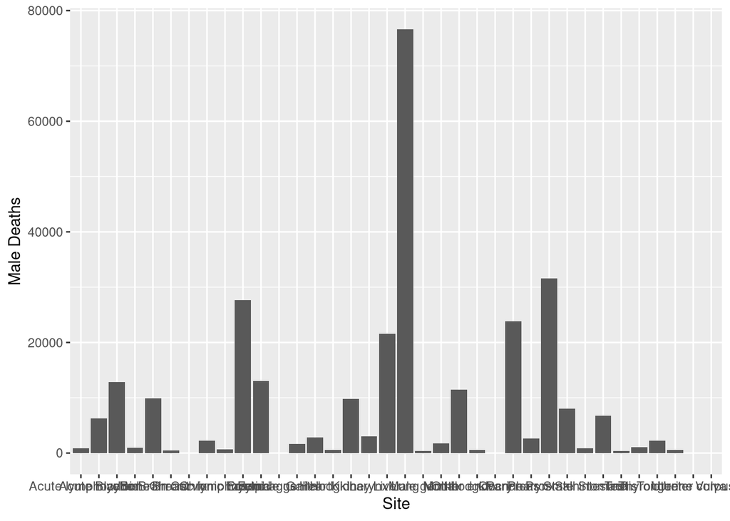

```r
# Not showing everything
cancer %>%
  ggplot(aes(x = str_to_sentence(Site), y = `Male Deaths`)) +
  geom_col() +
  labs(x = "Site")
```

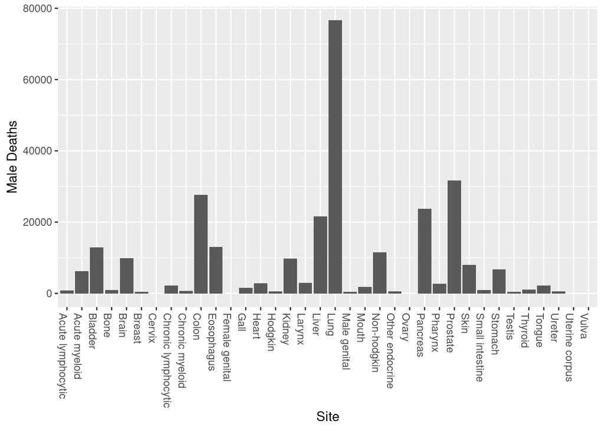

```r
# Rotate labels
cancer %>%
  ggplot(aes(x = str_to_sentence(Site), y = `Male Deaths`)) +
  geom_col() +
  labs(x = "Site") +
  theme(axis.text.x = element_text(angle = -90, hjust = 0))
```

Now, let’s just show the 5 highest.

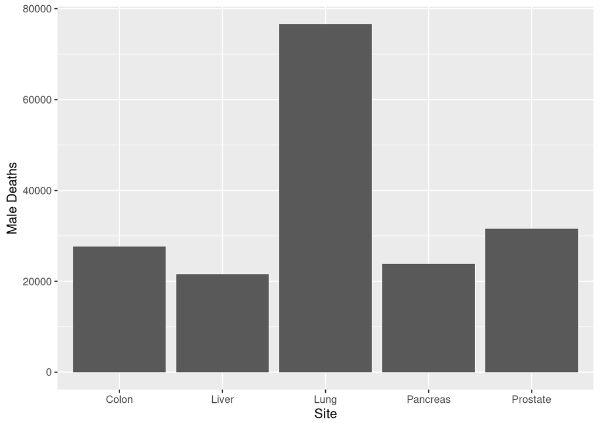

```r
cancer %>%
  arrange(desc(`Male Deaths`)) %>%
  slice(1:5) %>%
  ggplot(aes(x = str_to_sentence(Site), y = `Male Deaths`)) +
  labs(x = "Site") +
  geom_col()
```

Now it works, but even though we fed it sorted data the plot still comes out in alphabetical order.

# 2d) Child variants

Plot the MutantRead distributions for good (`QUAL == 200`) and bad (`QUAL < 200`) variants.

```r
child <- read_csv("Child_Variants.csv", guess_max = 1000000)
head(child)
```

```
## # A tibble: 6 × 11
##   CHR      POS dbSNP      REF   ALT    QUAL GENE   ENST     MutantReads COVERAGE
##   <chr>  <dbl> <chr>      <chr> <chr> <dbl> <chr>  <chr>          <dbl>    <dbl>
## 1 1      69270 .          A     G        16 OR4F5  ENST000…           3        4
## 2 1      69511 rs75062661 A     G       200 OR4F5  ENST000…          24       27
## 3 1      69761 .          A     T       200 OR4F5  ENST000…           8        8
## 4 1      69897 rs75758884 T     C        59 OR4F5  ENST000…           3        3
## 5 1     877831 rs6672356  T     C       200 SAMD11 ENST000…          10       11
## 6 1     881627 rs2272757  G     A       200 NOC2L  ENST000…          52       56
## # … with 1 more variable: MutantReadPercent <dbl>
```

We need to make the good/bad category column.

```r
child %<>%
  mutate(`Good or not` = if_else(QUAL == 200, "Good", "Bad"))

head(child)
```

```
## # A tibble: 6 × 12
##   CHR      POS dbSNP      REF   ALT    QUAL GENE   ENST     MutantReads COVERAGE
##   <chr>  <dbl> <chr>      <chr> <chr> <dbl> <chr>  <chr>          <dbl>    <dbl>
## 1 1      69270 .          A     G        16 OR4F5  ENST000…           3        4
## 2 1      69511 rs75062661 A     G       200 OR4F5  ENST000…          24       27
## 3 1      69761 .          A     T       200 OR4F5  ENST000…           8        8
## 4 1      69897 rs75758884 T     C        59 OR4F5  ENST000…           3        3
## 5 1     877831 rs6672356  T     C       200 SAMD11 ENST000…          10       11
## 6 1     881627 rs2272757  G     A       200 NOC2L  ENST000…          52       56
## # … with 2 more variables: MutantReadPercent <dbl>, Good or not <chr>
```

Now we can plot it. I did it on a log scale to make it a bit easier to look at.

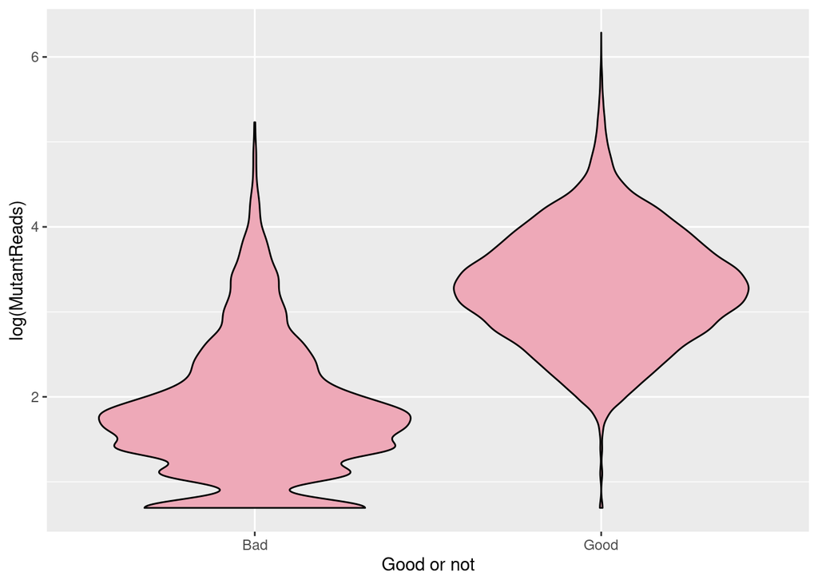

```r
child %>%
  ggplot(aes(x = `Good or not`, y = log(MutantReads))) +
  geom_violin(fill = "pink2", color = "black")
```

# Exercise 3 - Annotation, Scaling and Colors

## 3a) Themes

Set a theme and then redraw some stuff to see that it changes.

```r
theme_set(theme_bw(base_size = 16))
```

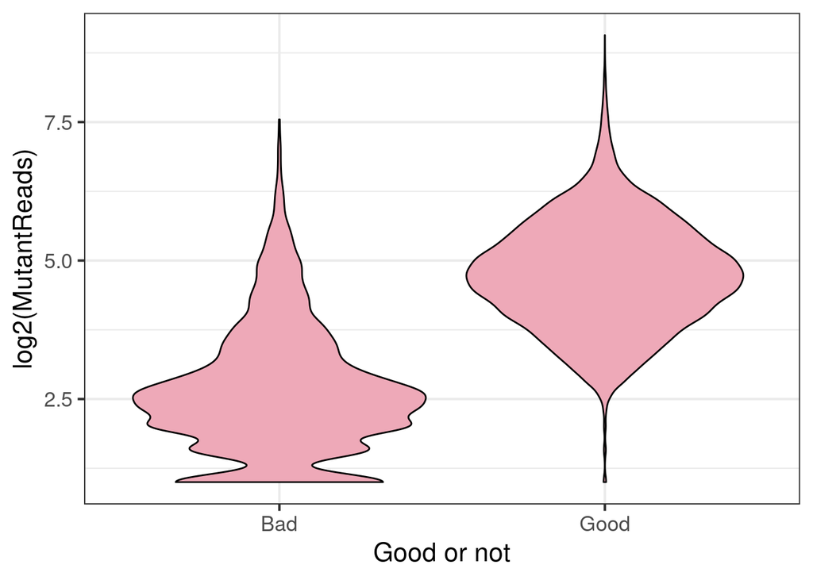

```r
child %>%
  ggplot(aes(x = `Good or not`, y = log2(MutantReads))) +
  geom_violin(fill = "pink2", color = "black")
```

Yep, that definitely looks different, as will every plot from now on. If we wanted to change it for a specific plot then we could easily do that too.

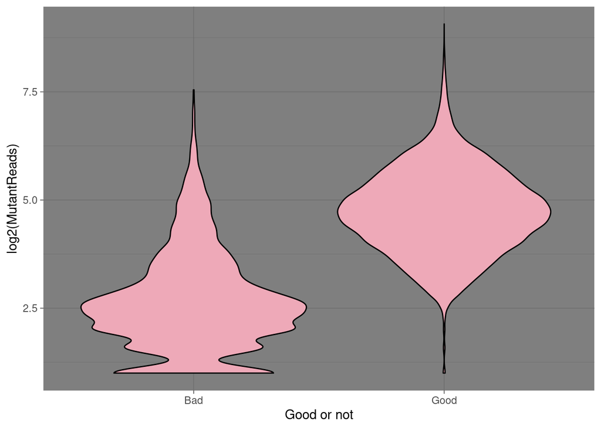

```r
child %>%
  ggplot(aes(x = `Good or not`, y = log2(MutantReads))) +
  geom_violin(fill = "pink2", color = "black") +
  theme_dark()
```

## 3b) Cancer

Redraw the previous bargraph, but with the axes flipped so we can see all of the categories and we don’t have to filter them. I’m also going to order the results by the data to make the plot clearer, and I’ve removed the cancers which males can’t get.

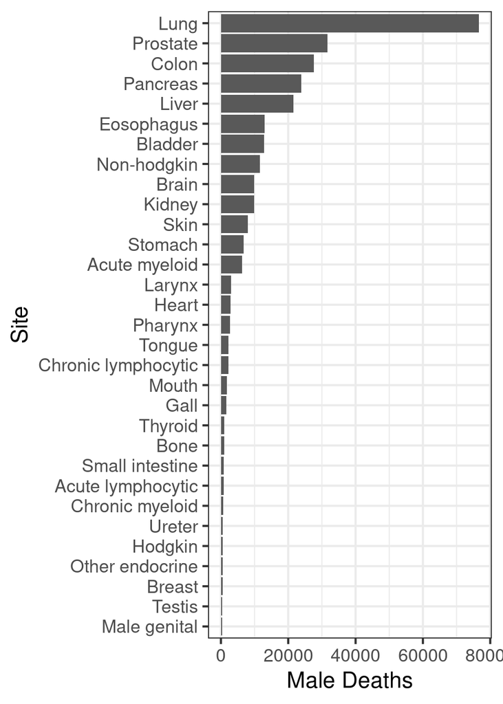

```r
cancer %>%
  filter(!is.na(`Male Deaths`)) %>%
  ggplot(aes(x = reorder(str_to_sentence(Site), `Male Deaths`), y = `Male Deaths`)) +
  geom_col() +
  xlab("Site")+
  coord_flip()
```

## 3c) Brain Bodyweight

Plot a scatterplot of brainweight vs bodyweight and make various customizations.

```r
brain <- read_tsv("brain_bodyweight.txt")
head(brain)
```

```
## # A tibble: 6 × 4
##   Species        Category         body  brain
##   <chr>          <chr>           <dbl>  <dbl>
## 1 Cow            Domesticated   465     423
## 2 Grey Wolf      Wild            36.3   120.
## 3 Goat           Domesticated    27.7   115
## 4 Guinea Pig     Wild             1.04    5.5
## 5 Diplodocus     Extinct      11700      50
## 6 Asian Elephant Wild          2547    4603
```

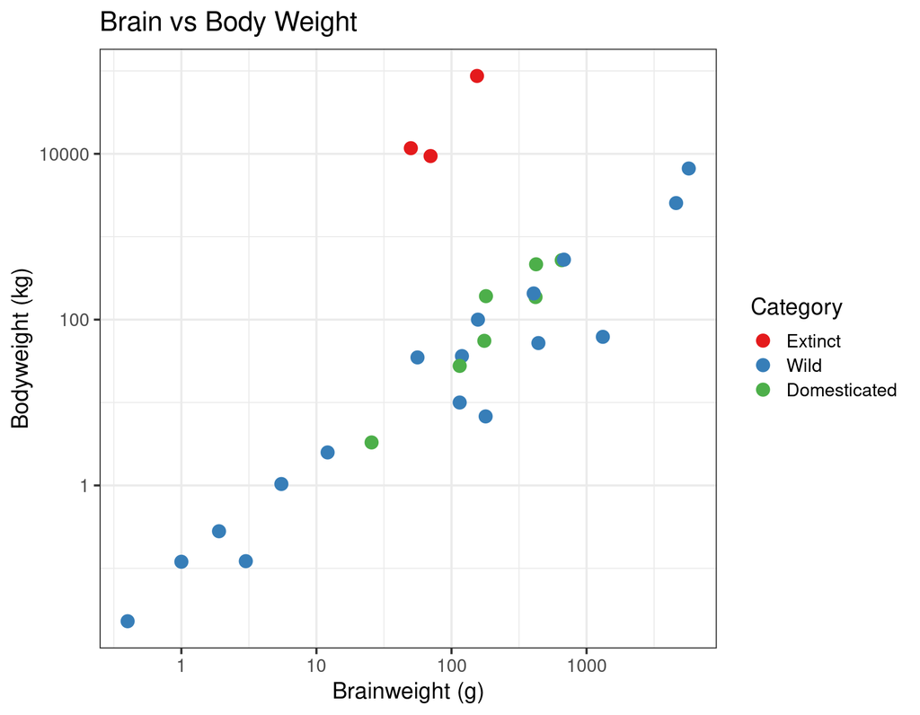

```r
brain %>%
  mutate(Category = factor(Category, levels = c("Extinct", "Wild", "Domesticated"))) %>%
  ggplot(aes(x = brain, y = body, color = Category))+
  geom_point(size = 4)+
  ggtitle("Brain vs Body Weight")+
  xlab("Brainweight (g)") +
  ylab("Bodyweight (kg)") +
  scale_y_log10() +
  scale_x_log10() +
  scale_color_brewer(palette = "Set1")
```

Finally do a barplot of all species showing their brainweight, but colored by their bodyweight and using a custom color scheme.

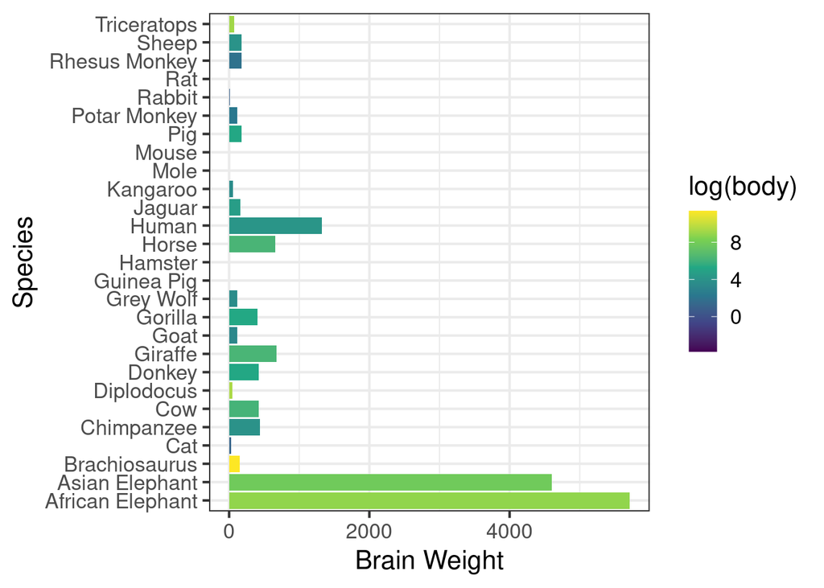

```r
brain %>%
  ggplot(aes(x = Species, y = brain, fill = log(body))) +
  geom_col() +
  coord_flip() +
  scale_fill_continuous(type = "viridis") +
  labs(y = "Brain Weight")
```